# RStanBook_chap04

Kasahara Masahiro

2022-07-21

## 5.1 重回帰

### データの散布図行列(図5.1)

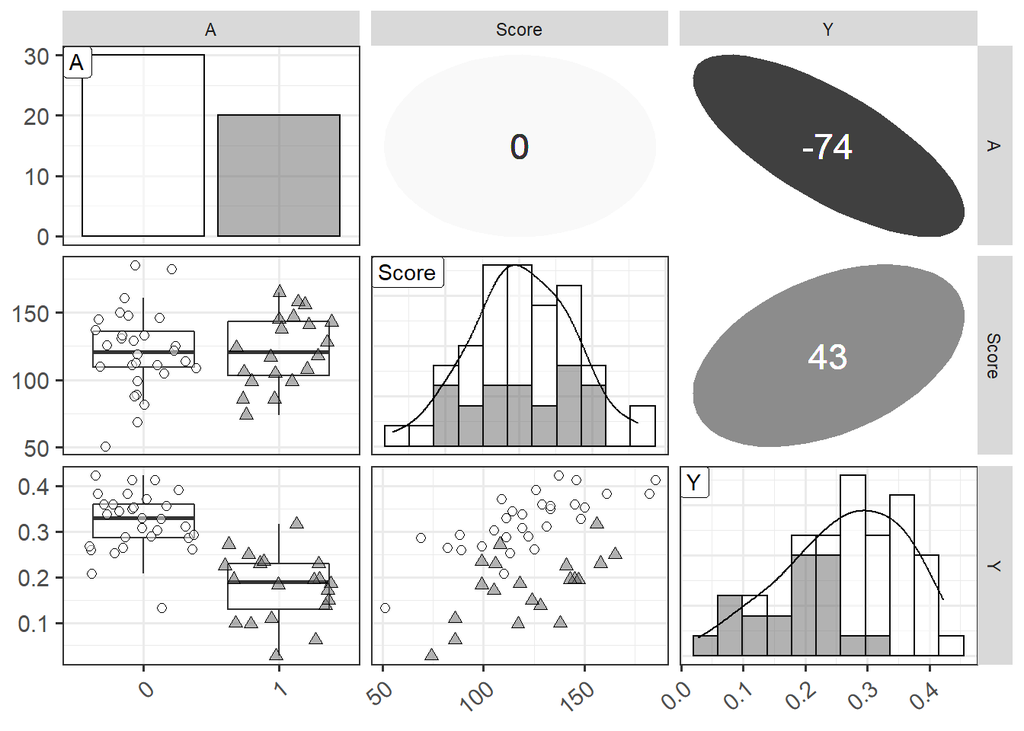

```r
library(ggplot2)
library(GGally)

set.seed(123)
d <- read.csv(file='input/data-attendance-1.txt')
d$A <- as.factor(d$A)

N_col <- ncol(d)
ggp <- ggpairs(d, upper='blank', diag='blank', lower='blank')

for (i in 1:N_col) {
  x <- d[,i]
  p <- ggplot(data.frame(x, A=d$A), aes(x)) +
    theme_bw(base_size=14) +
    theme(axis.text.x=element_text(angle=40, vjust=1, hjust=1))
  if (class(x) == 'factor') {
    p <- p + geom_bar(aes(fill=A), color='grey5')
  } else {
    bw <- (max(x)-min(x))/10
    p <- p + geom_histogram(binwidth=bw, aes(fill=A), color='grey5') +
      geom_line(eval(bquote(aes(y=..count..*.(bw)))), stat='density')
  }
  p <- p + geom_label(data=data.frame(x=-Inf, y=Inf, label=colnames(d)[i]), aes(x=x, y=y, label=label), hjust=0, vjust=1) +
    scale_fill_manual(values=alpha(c('white', 'grey40'), 0.5))
  ggp <- putPlot(ggp, p, i, i)
}

zcolat <- seq(-1, 1, length=81)
zcolre <- c(zcolat[1:40]+1, rev(zcolat[41:81]))

for (i in 1:(N_col-1)) {
  for (j in (i+1):N_col) {
    x <- as.numeric(d[,i])
    y <- as.numeric(d[,j])
    r <- cor(x, y, method='spearman', use='pairwise.complete.obs')
    zcol <- lattice::level.colors(r, at=zcolat, col.regions=grey(zcolre))
    textcol <- ifelse(abs(r) < 0.4, 'grey20', 'white')
    ell <- ellipse::ellipse(r, level=0.95, type='l', npoints=50, scale=c(.2, .2), centre=c(.5, .5))
    p <- ggplot(data.frame(ell), aes(x=x, y=y))
    p <- p + theme_bw() + theme(
      plot.background=element_blank(),
      panel.grid.major=element_blank(), panel.grid.minor=element_blank(),
      panel.border=element_blank(), axis.ticks=element_blank()) +
      geom_polygon(fill=zcol, color=zcol) +
      geom_text(data=NULL, x=.5, y=.5, label=100*round(r, 2), size=6, col=textcol)
    ggp <- putPlot(ggp, p, i, j)
  }
}

for (j in 1:(N_col-1)) {
  for (i in (j+1):N_col) {
    x <- d[,j]
    y <- d[,i]
    p <- ggplot(data.frame(x, y, gr=d$A), aes(x=x, y=y, fill=gr, shape=gr)) +
      theme_bw(base_size=14) +
      theme(axis.text.x=element_text(angle=40, vjust=1, hjust=1))
    if (class(x) == 'factor') {
      p <- p + geom_boxplot(aes(group=x), alpha=3/6, outlier.shape=NA, fill='white') +
        geom_point(position=position_jitter(w=0.4, h=0), size=2)
    } else {
      p <- p + geom_point(size=2)
    }
    p <- p + scale_shape_manual(values=c(21, 24)) +
      scale_fill_manual(values=alpha(c('white', 'grey40'), 0.5))
    ggp <- putPlot(ggp, p, i, j)
  }
}

#png(file='output/fig5-1.png', w=1600, h=1600, res=300)
print(ggp, left=0.3, bottom=0.3)
```

```r
#dev.off()
```

### 重回帰のモデル式(model5-3.stan)

```stan
data {
  int N;
  int<lower=0, upper=1> A[N];
  real<lower=0, upper=1> Score[N];
  real<lower=0, upper=1> Y[N];
}

parameters {
  real b1;
  real b2;
  real b3;
  real<lower=0> sigma;
}

transformed parameters {
  real mu[N];
  for (n in 1:N)
    mu[n] = b1 + b2*A[n] + b3*Score[n];
}

model {
  for (n in 1:N)
    Y[n] ~ normal(mu[n], sigma);
}

generated quantities {
  real y_pred[N];
  for (n in 1:N)
    y_pred[n] = normal_rng(mu[n], sigma); //XX_rngのXXにより分布を設定
}
```

#### transformed parameters

transformed parametersブロックでは、parametersブロックで宣言されたパラメータと低数値から、四則演算とlogなどの関数を使ってサンプリングする変数を作成する事が出来る。

#### generated quantities

generated quantitiesブロックでは、data・parameters・transformed parametersブロックで宣言されたパラメータ及び定数値から、四則演算とlogなどの関数を使って新たにサンプリングする変数を作ることが出来る。

### 重回帰モデル式の実行(run-model5-3.R)

```r
library(rstan)

d <- read.csv(file='input/data-attendance-1.txt')
data <- list(N=nrow(d), A=d$A, Score=d$Score/200, Y=d$Y)
fit <- sampling(model5.3, data=data, seed=1234)
```

```r
#save.image('output/result-model5-3.RData')
```

### 実測値と予測値のプロット(図5.3)

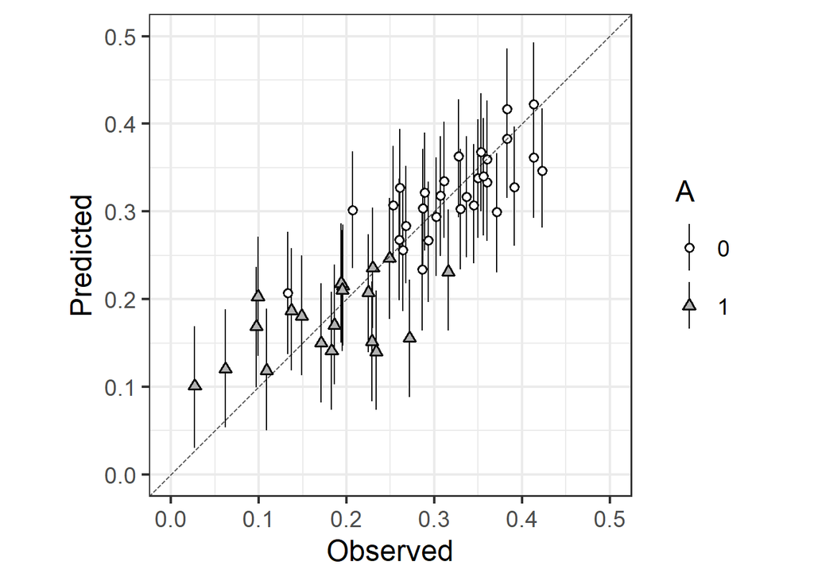

```r
library(ggplot2)

#load('output/result-model5-3.RData')
ms <- rstan::extract(fit)

qua <- apply(ms$y_pred, 2, quantile, prob=c(0.1, 0.5, 0.9))
d_est <- data.frame(d, t(qua), check.names=FALSE)
d_est$A <- as.factor(d_est$A)

p <- ggplot(data=d_est, aes(x=Y, y=`50%`, ymin=`10%`, ymax=`90%`, shape=A, fill=A)) +
  theme_bw(base_size=18) + theme(legend.key.height=grid::unit(2.5,'line')) +
  coord_fixed(ratio=1, xlim=c(0, 0.5), ylim=c(0, 0.5)) +
  geom_pointrange(size=0.5, color='grey5') +
  geom_abline(aes(slope=1, intercept=0), color='black', alpha=3/5, linetype='31') +
  scale_shape_manual(values=c(21, 24)) +
  scale_fill_manual(values=c('white', 'grey70')) +
  labs(x='Observed', y='Predicted') +
  scale_x_continuous(breaks=seq(from=0, to=0.5, by=0.1)) +
  scale_y_continuous(breaks=seq(from=0, to=0.5, by=0.1))
#ggsave(file='output/fig5-3.png', plot=p, dpi=300, w=5, h=4)
print(p)
```

### 図5.4

- 左: ε[n]の分布。テンセントその下の縦棒はそれぞれの分布のMAP推定値。
- 右: MAP推定値を集計して算出したヒストグラムと密度関数。
- 点線: 平均が0・標準偏差がmodel5-3.stanのsigmaのMAP推定値である正規分布。

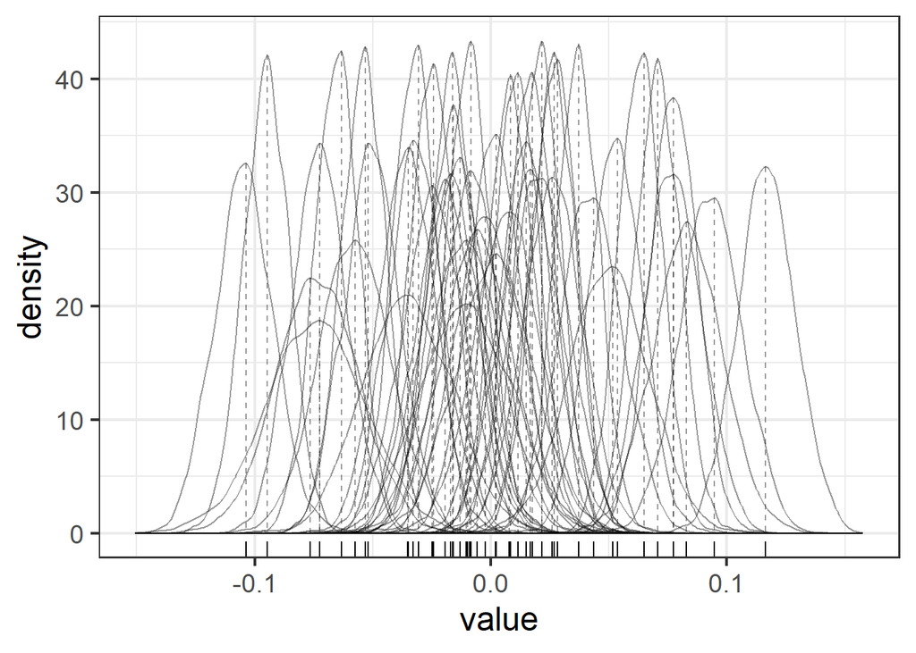

```r
library(dplyr)
library(ggplot2)

#load('output/result-model5-3.RData')
ms <- rstan::extract(fit)
N_mcmc <- length(ms$lp__)

noise_mcmc <- t(replicate(N_mcmc, d$Y)) - ms$mu

d_est <- data.frame(noise_mcmc, check.names=FALSE) %>%
  tidyr::pivot_longer(cols=everything(), names_to='Parameter') %>%
  mutate(PersonID = readr::parse_number(Parameter))

d_mode <- apply(noise_mcmc, 2, function(x) {
  dens <- density(x)
  mode_i <- which.max(dens$y)
  mode_x <- dens$x[mode_i]
  mode_y <- dens$y[mode_i]
  c(mode_x, mode_y)
}) %>%
  t() %>%
  data.frame() %>%
  magrittr::set_colnames(c('X', 'Y'))

p <- ggplot() +
  theme_bw(base_size=18) +
  geom_line(data=d_est, aes(x=value, group=PersonID), stat='density', color='black', alpha=0.4) +
  geom_segment(data=d_mode, aes(x=X, xend=X, y=Y, yend=0), color='black', linetype='dashed', alpha=0.4) +
  geom_rug(data=d_mode, aes(x=X), sides='b') +
  labs(x='value', y='density')
#ggsave(file='output/fig5-4-left.png', plot=p, dpi=300, w=4, h=3)
print(p)
```

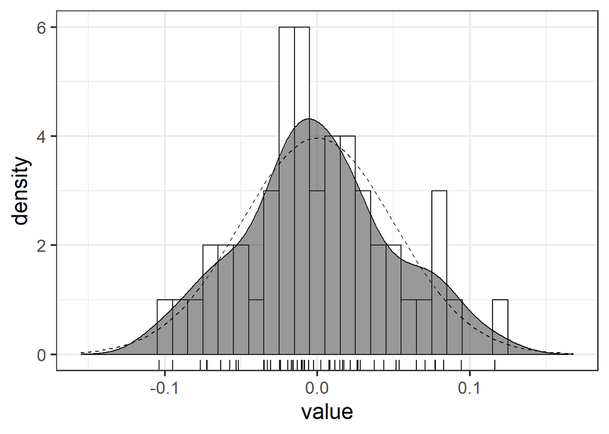

```r
s_dens <- density(ms$s)
s_MAP <- s_dens$x[which.max(s_dens$y)]
bw <- 0.01
p <- ggplot(data=d_mode, aes(x=X)) +
  theme_bw(base_size=18) +
  geom_histogram(binwidth=bw, color='black', fill='white') +
  geom_density(eval(bquote(aes(y=..count..*.(bw)))), alpha=0.5, color='black', fill='gray20') +
  geom_rug(sides='b') +
  stat_function(fun=function(x) nrow(d)*bw*dnorm(x, mean=0, sd=s_MAP), linetype='dashed') +
  labs(x='value', y='density') +
  xlim(range(density(d_mode$X)$x))
#ggsave(file='output/fig5-4-right.png', plot=p, dpi=300, w=4, h=3)
print(p)
```

* 右の図が少し異なる。

### MCMCサンプルの散布図行列(図5.5)

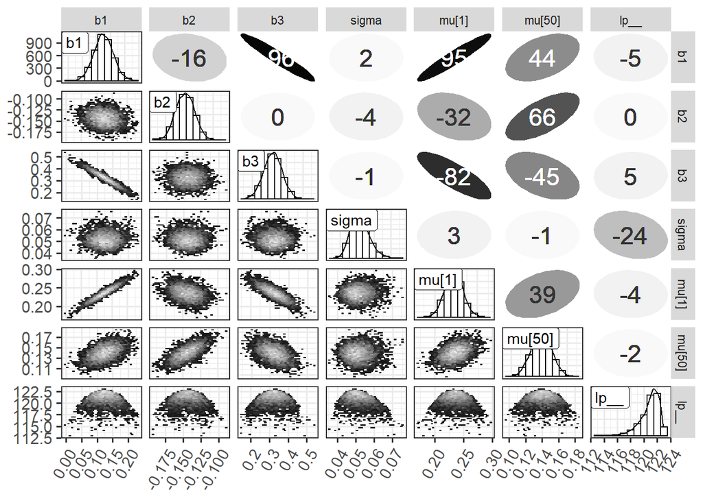

```r
library(ggplot2)
library(GGally)
library(hexbin)

#load('output/result-model5-3.RData')
ms <- rstan::extract(fit)

d <- data.frame(b1=ms$b1, b2=ms$b2, b3=ms$b3, sigma=ms$sigma, `mu[1]`=ms$mu[,1], `mu[50]`=ms$mu[,50], lp__=ms$lp__, check.names=FALSE)
N_col <- ncol(d)
ggp <- ggpairs(d, upper='blank', diag='blank', lower='blank')

for (i in 1:N_col) {
  x <- d[,i]
  bw <- (max(x)-min(x))/10
  p <- ggplot(data.frame(x), aes(x)) +
    theme_bw(base_size=14) +
    theme(axis.text.x=element_text(angle=60, vjust=1, hjust=1)) +
    geom_histogram(binwidth=bw, fill='white', color='grey5') +
    geom_line(eval(bquote(aes(y=..count..*.(bw)))), stat='density') +
    geom_label(data=data.frame(x=-Inf, y=Inf, label=colnames(d)[i]), aes(x=x, y=y, label=label), hjust=0, vjust=1)
  ggp <- putPlot(ggp, p, i, i)
}

zcolat <- seq(-1, 1, length=81)
zcolre <- c(zcolat[1:40]+1, rev(zcolat[41:81]))

for (i in 1:(N_col-1)) {
  for (j in (i+1):N_col) {
    x <- as.numeric(d[,i])
    y <- as.numeric(d[,j])
    r <- cor(x, y, method='spearman', use='pairwise.complete.obs')
    zcol <- lattice::level.colors(r, at=zcolat, col.regions=grey(zcolre))
    textcol <- ifelse(abs(r) < 0.4, 'grey20', 'white')
    ell <- ellipse::ellipse(r, level=0.95, type='l', npoints=50, scale=c(.2, .2), centre=c(.5, .5))
    p <- ggplot(data.frame(ell), aes(x=x, y=y)) + theme_bw() + theme(
      plot.background=element_blank(),
      panel.grid.major=element_blank(), panel.grid.minor=element_blank(),
      panel.border=element_blank(), axis.ticks=element_blank()) +
      geom_polygon(fill=zcol, color=zcol) +
      geom_text(data=NULL, x=.5, y=.5, label=100*round(r, 2), size=6, col=textcol)
    ggp <- putPlot(ggp, p, i, j)
  }
}

for (j in 1:(N_col-1)) {
  for (i in (j+1):N_col) {
    x <- d[,j]
    y <- d[,i]
    p <- ggplot(data.frame(x, y), aes(x=x, y=y)) +
      theme_bw(base_size=14) +
      theme(axis.text.x=element_text(angle=60, vjust=1, hjust=1)) +
      geom_hex() +
      scale_fill_gradientn(colours=gray.colors(7, start=0.1, end=0.9))
    ggp <- putPlot(ggp, p, i, j)
  }
}

#png(file='output/fig5-5.png', w=2100, h=2100, res=300)
print(ggp, left=0.6, bottom=0.6)
```

```r
#dev.off()
```

## 5.2 二項ロジスティック回帰

### データの散布図行列(図5.6)

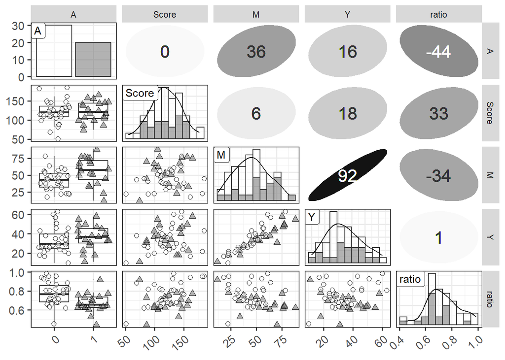

```r
library(ggplot2)
library(GGally)

set.seed(1)
d <- read.csv(file='input/data-attendance-2.txt')[,-1]
d <- transform(d, ratio=Y/M)
d$A <- as.factor(d$A)
N_col <- ncol(d)
ggp <- ggpairs(d, upper='blank', diag='blank', lower='blank')

for (i in 1:N_col) {
  x <- d[,i]
  p <- ggplot(data.frame(x, A=d$A), aes(x)) +
    theme_bw(base_size=14) +
    theme(axis.text.x=element_text(angle=40, vjust=1, hjust=1))
  if (class(x) == 'factor') {
    p <- p + geom_bar(aes(fill=A), color='grey20')
  } else {
    bw <- (max(x)-min(x))/10
    p <- p + geom_histogram(aes(fill=A), color='grey20', binwidth=bw) +
      geom_line(eval(bquote(aes(y=..count..*.(bw)))), stat='density')
  }
  p <- p + geom_label(data=data.frame(x=-Inf, y=Inf, label=colnames(d)[i]), aes(x=x, y=y, label=label), hjust=0, vjust=1) +
    scale_fill_manual(values=alpha(c('white', 'grey40'), 0.5))
  ggp <- putPlot(ggp, p, i, i)
}

zcolat <- seq(-1, 1, length=81)
zcolre <- c(zcolat[1:40]+1, rev(zcolat[41:81]))

for (i in 1:(N_col-1)) {
  for (j in (i+1):N_col) {
    x <- as.numeric(d[,i])
    y <- as.numeric(d[,j])
    r <- cor(x, y, method='spearman', use='pairwise.complete.obs')
    zcol <- lattice::level.colors(r, at=zcolat, col.regions=grey(zcolre))
    textcol <- ifelse(abs(r) < 0.4, 'grey20', 'white')
    ell <- ellipse::ellipse(r, level=0.95, type='l', npoints=50, scale=c(.2, .2), centre=c(.5, .5))
    p <- ggplot(data.frame(ell), aes(x=x, y=y)) + theme_bw() + theme(
      plot.background=element_blank(),
      panel.grid.major=element_blank(), panel.grid.minor=element_blank(),
      panel.border=element_blank(), axis.ticks=element_blank()) +
      geom_polygon(fill=zcol, color=zcol) +
      geom_text(data=NULL, x=.5, y=.5, label=100*round(r, 2), size=6, col=textcol)
    ggp <- putPlot(ggp, p, i, j)
  }
}

for (j in 1:(N_col-1)) {
  for (i in (j+1):N_col) {
    x <- d[,j]
    y <- d[,i]
    p <- ggplot(data.frame(x, y, gr=d$A), aes(x=x, y=y, fill=gr, shape=gr)) +
      theme_bw(base_size=14) +
      theme(axis.text.x=element_text(angle=40, vjust=1, hjust=1))
    if (class(x) == 'factor') {
      p <- p + geom_boxplot(aes(group=x), alpha=3/6, outlier.size=0, fill='white') +
        geom_point(position=position_jitter(w=0.4, h=0), size=2)
    } else {
      p <- p + geom_point(size=2)
    }
    p <- p + scale_shape_manual(values=c(21, 24)) +
      scale_fill_manual(values=alpha(c('white', 'grey40'), 0.5))
    ggp <- putPlot(ggp, p, i, j)
  }
}

#png(file='output/fig5-6.png', w=2000, h=2000, res=300)
print(ggp, left=0.3, bottom=0.3)
```

```r
#dev.off()
```

### 二項ロジスティック回帰のモデル式(model5-4.stan)

```stan
data {
  int N;
  int<lower=0, upper=1> A[N];
  real<lower=0, upper=1> Score[N];
  int<lower=0> M[N];
  int<lower=0> Y[N];
}

parameters {
  real b1;
  real b2;
  real b3;
}

transformed parameters {
  real q[N];
  for (n in 1:N)
    q[n] = inv_logit(b1 + b2*A[n] + b3*Score[n]);
}

model {
  for (n in 1:N)
    Y[n] ~ binomial(M[n], q[n]);
}

generated quantities {
  real y_pred[N];
  for (n in 1:N)
    y_pred[n] = binomial_rng(M[n], q[n]);
}
```

- 説明変数2値→二項ロジスティック回帰
- 説明変数3値以上→ロジスティック回帰(順序ロジスティック回帰)

### 二項ロジスティックモデルの実行(run-model5.4.R)

```r
library(rstan)

d <- read.csv(file='input/data-attendance-2.txt')
data <- list(N=nrow(d), A=d$A, Score=d$Score/200, M=d$M, Y=d$Y)
fit <- sampling(model5.4, data=data, seed=1234)
```

```r
#save.image('output/result-model5-4.RData')
```

### 実測値と予測値のプロット(図5.8)

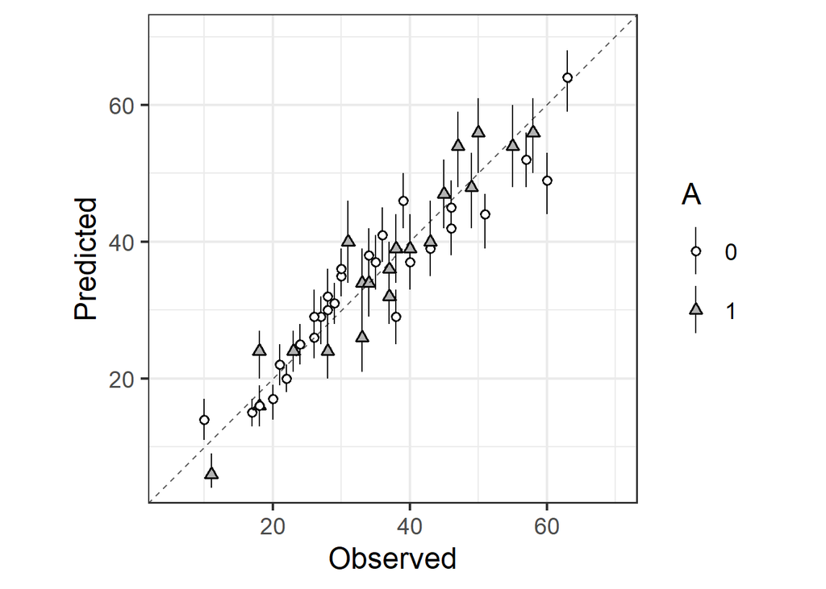

```r
library(ggplot2)

#load('output/result-model5-4.RData')
ms <- rstan::extract(fit)

qua <- apply(ms$y_pred, 2, quantile, prob=c(0.1, 0.5, 0.9))
d_est <- data.frame(d, t(qua), check.names=FALSE)
d_est$A <- as.factor(d_est$A)

p <- ggplot(data=d_est, aes(x=Y, y=`50%`, ymin=`10%`, ymax=`90%`, shape=A, fill=A)) +
  theme_bw(base_size=18) + theme(legend.key.height=grid::unit(2.5,'line')) +
  coord_fixed(ratio=1, xlim=c(5, 70), ylim=c(5, 70)) +
  geom_pointrange(size=0.5, color='grey5') +
  geom_abline(aes(slope=1, intercept=0), color='black', alpha=3/5, linetype='dashed') +
  scale_shape_manual(values=c(21, 24)) +
  scale_fill_manual(values=c('white', 'grey70')) +
  labs(x='Observed', y='Predicted') +
  scale_x_continuous(breaks=seq(from=0, to=70, by=20)) +
  scale_y_continuous(breaks=seq(from=0, to=70, by=20))
#ggsave(file='output/fig5-8.png', plot=p, dpi=300, w=5, h=4)
print(p)
```